# mlr

Xiaosong Jin

2018-05-04

# 1 Introduction

mlr包可谓是机器学习的一大利器，该包综合了诸多的R机器学习包，统一了语法，提供了大量便捷的工具，同时使调参和模型选择更加便捷。

# 2 Download mlr

```r
# install.packages("mlr", denpencies = T)
```

# 3 Quick start

在系统的学习mlr包之前，我们先用其做一个简单的案例，先见识一下其独特的语法。下面我们就用大家所熟悉的iris数据开始做一个分类模型：  
注：下面仅是一个简单的举例，很多地方并不完善。

```r
## 加载mlr包，并且确定数据
library(mlr)
dat <- iris

## 定义任务
task <- makeClassifTask(data = dat, target = "Species")

## 定义学习器
lrn <- makeLearner("classif.lda")

## 创建训练集和测试集
set.seed(45)
n <- nrow(dat)
train_set <- sample(n, size = 2/3*n)
test_set  <- setdiff(1:n, train_set)

## 训练模型
model_lda <- train(learner = lrn, task = task, subset = train_set)

## 预测
pred_lda <- predict(model_lda, task = task, subset = test_set)

## 模型评估
lda_evaluate <- performance(pred_lda, measures = list(mmce, acc))
lda_evaluate
```

```
## mmce  acc
## 0.04 0.96
```

# 4 Tasks

在本部分，主要总结了如何创建各类任务、如何访问任务和如何修改任务。其中如何访问任务中包含了如何获取任务中的各种数据信息。

## 4.1 **Task types and creation**

mlr包中提供了以下几种任务：

- RegrTask for regression problems（回归任务）
- ClassifTask for binary and multi-class classification problems（分类任务）
- SurvTask for survival analysis（生存分析）
- ClusterTask for cluster analysis（聚类分析）
- MultilabelTask for multilabel classification problems（多标签分类）
- CostSensTask for general cost-sensitive classification (with example-specific costs)（成本敏感型分类）

下面我们分别用简短的例子去实现：

### 4.1.1 Regression

```r
data(BostonHousing, package = "mlbench")
regr_task <- makeRegrTask(data = BostonHousing, target = "medv")
regr_task
```

```
## Supervised task: BostonHousing
## Type: regr
## Target: medv
## Observations: 506
## Features:
##    numerics     factors     ordered functionals
##          12           1           0           0
## Missings: FALSE
## Has weights: FALSE
## Has blocking: FALSE
## Has coordinates: FALSE
```

### 4.1.2 Classification

```r
data(BreastCancer, package = "mlbench")
df <- BreastCancer
df$Id <- NULL
classif_task <- makeClassifTask(data = df, target = "Class", positive = "malignant")
classif_task
```

```
## Supervised task: df
## Type: classif
## Target: Class
## Observations: 699
## Features:
##    numerics     factors     ordered functionals
##           0           4           5           0
## Missings: TRUE
## Has weights: FALSE
## Has blocking: FALSE
## Has coordinates: FALSE
## Classes: 2
##    benign malignant
##       458       241
## Positive class: malignant
```

### 4.1.3 Survival analysis

```r
data(lung, package = "survival")
lung$status <- (lung$status == 2)  #将此列转换为逻辑型变量
surv_task <- makeSurvTask(data = lung, target = c("time", "status"))
surv_task
```

```
## Supervised task: lung
## Type: surv
## Target: time,status
## Events: 165
## Observations: 228
## Features:
##    numerics     factors     ordered functionals
##           8           0           0           0
## Missings: TRUE
## Has weights: FALSE
## Has blocking: FALSE
## Has coordinates: FALSE
```

### 4.1.4 Multilabel classification

```r
yeast <- getTaskData(yeast.task)
labels <- colnames(yeast)[1:14]
yeast_task <- makeMultilabelTask(data = yeast, target = labels)
yeast_task
```

```
## Supervised task: yeast
## Type: multilabel
## Target: label1,label2,label3,label4,label5,label6,label7,label8,label9,label10,label11,label12,label13,label14
## Observations: 2417
## Features:
##    numerics     factors     ordered functionals
##         103           0           0           0
## Missings: FALSE
## Has weights: FALSE
## Has blocking: FALSE
## Has coordinates: FALSE
## Classes: 14
##  label1  label2  label3  label4  label5  label6  label7  label8  label9
##     762    1038     983     862     722     597     428     480     178
## label10 label11 label12 label13 label14
##     253     289    1816    1799      34
```

### 4.1.5 Cluster analysis

```r
data(mtcars, package = "datasets")
cluster_task <- makeClusterTask(data = mtcars)
cluster_task
```

```
## Unsupervised task: mtcars
## Type: cluster
## Observations: 32
## Features:
##    numerics     factors     ordered functionals
##          11           0           0           0
## Missings: FALSE
## Has weights: FALSE
## Has blocking: FALSE
## Has coordinates: FALSE
```

### 4.1.6 Cost-sensitive classification

```r
df <- iris
cost <- matrix(runif(150 * 3, 0, 2000), 150) * (1 - diag(3))[df$Species,]
df$Species <- NULL

costsens_task <- makeCostSensTask(data = df, cost = cost)
costsens_task
```

```
## Supervised task: df
## Type: costsens
## Observations: 150
## Features:
##    numerics     factors     ordered functionals
##           4           0           0           0
## Missings: FALSE
## Has blocking: FALSE
## Has coordinates: FALSE
## Classes: 3
## y1, y2, y3
```

## 4.2 **Accessing a learning task**

本小节涉及两个方面：访问任务和获取任务中的数据信息。

### 4.2.1 access task

```r
getTaskDesc(classif_task)           #返回最详细的任务描述
```

```
## $id
## [1] "df"
##
## $type
## [1] "classif"
##
## $target
## [1] "Class"
##
## $size
## [1] 699
##
## $n.feat
##    numerics     factors     ordered functionals
##           0           4           5           0
##
## $has.missings
## [1] TRUE
##
## $has.weights
## [1] FALSE
##
## $has.blocking
## [1] FALSE
##
## $has.coordinates
## [1] FALSE
##
## $class.levels
## [1] "benign"    "malignant"
##
## $positive
## [1] "malignant"
##
## $negative
## [1] "benign"
##
## $class.distribution
##
##    benign malignant
##       458       241
##
## attr(,"class")
## [1] "ClassifTaskDesc"    "SupervisedTaskDesc" "TaskDesc"
```

```r
getTaskId(classif_task)             #返回任务的ID
```

```
## [1] "df"
```

```r
getTaskType(classif_task)           #返回任务类型
```

```
## [1] "classif"
```

```r
getTaskTargetNames(classif_task)    #返回目标变量名
```

```
## [1] "Class"
```

```r
getTaskSize(classif_task)           #返回数据大小
```

```
## [1] 699
```

```r
getTaskNFeats(classif_task)         #返回输入变量
```

```
## [1] 9
```

```r
getTaskClassLevels(classif_task)    #返回分类任务当中的'类'
```

```
## [1] "benign"    "malignant"
```

### 4.2.2 extract data

```r
head(getTaskData(classif_task))     #获取任务数据
```

```
##   Cl.thickness Cell.size Cell.shape Marg.adhesion Epith.c.size Bare.nuclei
## 1            5         1          1             1            2           1
## 2            5         4          4             5            7          10
## 3            3         1          1             1            2           2
## 4            6         8          8             1            3           4
## 5            4         1          1             3            2           1
## 6            8        10         10             8            7          10
##   Bl.cromatin Normal.nucleoli Mitoses     Class
## 1           3               1       1    benign
## 2           3               2       1    benign
## 3           3               1       1    benign
## 4           3               7       1    benign
## 5           3               1       1    benign
## 6           9               7       1 malignant
```

```r
getTaskFeatureNames(classif_task)   #获取输入变量名
```

```
## [1] "Cl.thickness"    "Cell.size"       "Cell.shape"      "Marg.adhesion"
## [5] "Epith.c.size"    "Bare.nuclei"     "Bl.cromatin"     "Normal.nucleoli"
## [9] "Mitoses"
```

```r
head(getTaskTargets(classif_task))  #获取目标变量名
```

```
## [1] benign    benign    benign    benign    benign    malignant
## Levels: benign malignant
```

```r
head(getTaskCosts(costsens_task))   #获取成本矩阵
```

```
##      y1        y2        y3
## [1,]  0  707.3011  932.5762
## [2,]  0   77.8694 1531.8597
## [3,]  0  984.2454  753.4774
## [4,]  0  740.8373  797.5681
## [5,]  0 1457.0867 1711.5323
## [6,]  0 1129.0749 1249.6415
```

## 4.3 **Modifying a learning task**

下面演示部分修改任务的操作，详细的操作请在https://www.rdocumentation.org/packages/mlr/versions/2.12.1/topics/capLargeValues中查看。后续我会补充进来…

### 4.3.1 subsetTask

```r
## 设定一个子任务（挑选部分观测建立任务）
cluster_task_sub <- subsetTask(cluster_task, subset = 4:17)
cluster_task_sub
```

```
## Unsupervised task: mtcars
## Type: cluster
## Observations: 14
## Features:
##    numerics     factors     ordered functionals
##          11           0           0           0
## Missings: FALSE
## Has weights: FALSE
## Has blocking: FALSE
## Has coordinates: FALSE
```

### 4.3.2 removeConstantFeatures

```r
## 移除恒定值的自变量
removeConstantFeatures(classif_task)
```

```
## Supervised task: df
## Type: classif
## Target: Class
## Observations: 699
## Features:
##    numerics     factors     ordered functionals
##           0           4           5           0
## Missings: TRUE
## Has weights: FALSE
## Has blocking: FALSE
## Has coordinates: FALSE
## Classes: 2
##    benign malignant
##       458       241
## Positive class: malignant
```

### 4.3.3 dropFeatures

```r
## 移除选中的自变量
dropFeatures(classif_task, c("Cell.size", "Cell.shape"))
```

```
## Supervised task: df
## Type: classif
## Target: Class
## Observations: 699
## Features:
##    numerics     factors     ordered functionals
##           0           4           3           0
## Missings: TRUE
## Has weights: FALSE
## Has blocking: FALSE
## Has coordinates: FALSE
## Classes: 2
##    benign malignant
##       458       241
## Positive class: malignant
```

### 4.3.4 normalizeFeatures

```r
## 对数值型变量标准化
task <- normalizeFeatures(cluster_task, method = "range")
summary(getTaskData(task))
```

```
##       mpg              cyl              disp              hp
##  Min.   :0.0000   Min.   :0.0000   Min.   :0.0000   Min.   :0.0000
##  1st Qu.:0.2138   1st Qu.:0.0000   1st Qu.:0.1240   1st Qu.:0.1572
##  Median :0.3745   Median :0.5000   Median :0.3123   Median :0.2509
##  Mean   :0.4124   Mean   :0.5469   Mean   :0.3982   Mean   :0.3346
##  3rd Qu.:0.5277   3rd Qu.:1.0000   3rd Qu.:0.6358   3rd Qu.:0.4523
##  Max.   :1.0000   Max.   :1.0000   Max.   :1.0000   Max.   :1.0000
##       drat              wt              qsec              vs
##  Min.   :0.0000   Min.   :0.0000   Min.   :0.0000   Min.   :0.0000
##  1st Qu.:0.1475   1st Qu.:0.2731   1st Qu.:0.2848   1st Qu.:0.0000
##  Median :0.4309   Median :0.4633   Median :0.3821   Median :0.0000
##  Mean   :0.3855   Mean   :0.4358   Mean   :0.3987   Mean   :0.4375
##  3rd Qu.:0.5346   3rd Qu.:0.5362   3rd Qu.:0.5238   3rd Qu.:1.0000
##  Max.   :1.0000   Max.   :1.0000   Max.   :1.0000   Max.   :1.0000
##        am              gear             carb
##  Min.   :0.0000   Min.   :0.0000   Min.   :0.0000
##  1st Qu.:0.0000   1st Qu.:0.0000   1st Qu.:0.1429
##  Median :0.0000   Median :0.5000   Median :0.1429
##  Mean   :0.4062   Mean   :0.3438   Mean   :0.2589
##  3rd Qu.:1.0000   3rd Qu.:0.5000   3rd Qu.:0.4286
##  Max.   :1.0000   Max.   :1.0000   Max.   :1.0000
```

# 5 Learners

上面把有关task的内容介绍了一下，下面就该学习有关学习器的内容了。下面主要涉及到了如何构建学习器、获取学习器的信息、修改学习器和查询学习器列表。

## 5.1 **Constructing a learner**

在构建学习器时，不仅可以指定学习器的名称，还可以设置超参数、预测的输出类型（标签或概率）、设定学习器ID。下面简单地建立5个学习器展示一下如何构建学习器：

在构建学习器时，有以下下三个比较重要的参数：

- 学习器名称：classif/regr/surv/cluster/multilabel.
- 超参设置：可以通过…参数或者是par.vars参数来指定
- 当测试集的因子水平少于训练集时，我们可以使用`fix.factors.prediction = T`来避免因此导致的错误。

指的一提的是，mlr包还提供了一个函数`makeLearners()`，该函数可以同时对同一个数据建立多个模型。

### 5.1.1 makeLearner

```r
## 构建随机森林学习器，并且设定输出结果是标签的概率
classif_lrn <- makeLearner("classif.randomForest", predict.type = "prob", fix.factors.prediction = TRUE)

## 建立回归学习器，并且设置相关参数（目前不知道参数是干啥的，待解决）
regr_lrn <- makeLearner("regr.gbm", par.vals = list(n.trees = 500, interaction.depth = 3))

## 建立Cox风险模型，并设定模型ID
surv_lrn <- makeLearner("surv.coxph", id = "cph")

## 建立K-Means模型，设定聚为5类
cluster_lrn = makeLearner("cluster.kmeans", centers = 5)

## 建立Multilabel Random Ferns算法
multilabel_lrn = makeLearner("multilabel.rFerns")
```

### 5.1.2 makeLearners

```r
## 建立回归树和线性判别模型，并且指定返回模型的类型和输出标签是概率
rp_lda_lrn <- makeLearners(c("rpart", "lda"), type = "classif", predict.type = "prob")
```

## 5.2 **Accessing a learner**

获取学习器的相关信息的时候有两种方法，第一种就是使用`$`提取，第二种就是使用mlr包中的函数：

- 查看学习器的超参数：`getHyperPars()`
- 查看学习器的参数集：`getParamSet()`
- 查看学习器的简称：`getLearnerShortName()`
- 查看学习器类型：`getLearnerType()`
- 查看学习器需要下载的包：`getLearnerPackaages()`

```r
cluster_lrn$par.vals
```

```
## $centers
## [1] 5
```

```r
getHyperPars(cluster_lrn)
```

```
## $centers
## [1] 5
```

```r
getParamSet(cluster_lrn)
```

```
##               Type len           Def                             Constr
## centers    untyped   -             -                                  -
## iter.max   integer   -            10                           1 to Inf
## nstart     integer   -             1                           1 to Inf
## algorithm discrete   - Hartigan-Wong Hartigan-Wong,Lloyd,Forgy,MacQueen
## trace      logical   -             -                                  -
##           Req Tunable Trafo
## centers     -    TRUE     -
## iter.max    -    TRUE     -
## nstart      -    TRUE     -
## algorithm   -    TRUE     -
## trace       -   FALSE     -
```

```r
getParamSet(cluster_lrn)
```

```
##               Type len           Def                             Constr
## centers    untyped   -             -                                  -
## iter.max   integer   -            10                           1 to Inf
## nstart     integer   -             1                           1 to Inf
## algorithm discrete   - Hartigan-Wong Hartigan-Wong,Lloyd,Forgy,MacQueen
## trace      logical   -             -                                  -
##           Req Tunable Trafo
## centers     -    TRUE     -
## iter.max    -    TRUE     -
## nstart      -    TRUE     -
## algorithm   -    TRUE     -
## trace       -   FALSE     -
```

```r
getLearnerId(cluster_lrn)
```

```
## [1] "cluster.kmeans"
```

```r
getLearnerShortName(cluster_lrn)
```

```
## [1] "kmeans"
```

```r
getLearnerType(cluster_lrn)
```

```
## [1] "cluster"
```

```r
getLearnerPackages(cluster_lrn)
```

```
## [1] "stats" "clue"
```

## 5.3 **Modifying a learner**

与修改学习任务一样，在mlr包中也提供了修改学习器的函数，方便我们去修改某个学习器，而不用去重新创建，大大提高了工作效率。

下面主要演示了如何修改学习器ID、修改学习器返回目标变量的类型、修改参数、恢复自定义参数的默认值。

### 5.3.1 setLearnerId

```r
surv_lrn <- setLearnerId(surv_lrn, "CoxModel")
surv_lrn
```

```
## Learner CoxModel from package survival
## Type: surv
## Name: Cox Proportional Hazard Model; Short name: coxph
## Class: surv.coxph
## Properties: numerics,factors,weights
## Predict-Type: response
## Hyperparameters:
```

### 5.3.2 setPredictType

```r
classif_lrn <- setPredictType(classif_lrn, "response")
classif_lrn
```

```
## Learner classif.randomForest from package randomForest
## Type: classif
## Name: Random Forest; Short name: rf
## Class: classif.randomForest
## Properties: twoclass,multiclass,numerics,factors,ordered,prob,class.weights,oobpreds,featimp
## Predict-Type: response
## Hyperparameters:
```

### 5.3.3 setHyperPars

```r
cluster_lrn <- setHyperPars(cluster_lrn, centers = 4)
cluster_lrn
```

```
## Learner cluster.kmeans from package stats,clue
## Type: cluster
## Name: K-Means; Short name: kmeans
## Class: cluster.kmeans
## Properties: numerics,prob
## Predict-Type: response
## Hyperparameters: centers=4
```

### 5.3.4 removeHyperPars

```r
regr_lrn <- removeHyperPars(regr_lrn, c("n.trees", "interaction.depth"))
regr_lrn
```

```
## Learner regr.gbm from package gbm
## Type: regr
## Name: Gradient Boosting Machine; Short name: gbm
## Class: regr.gbm
## Properties: missings,numerics,factors,weights,featimp
## Predict-Type: response
## Hyperparameters: distribution=gaussian,keep.data=FALSE
```

## 5.4 **Listing learners**

在mlr包中提供了上百种模型去供我们调用，如下图所示：

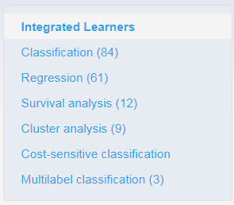

```r
## 返回mlr里面的分类学习器和其对应的包
lrns <- listLearners()
head(lrns[c("class", "package")])
```

```
##                 class      package
## 1         classif.ada    ada,rpart
## 2  classif.adaboostm1        RWeka
## 3 classif.bartMachine  bartMachine
## 4    classif.binomial        stats
## 5  classif.blackboost mboost,party
## 6    classif.boosting adabag,rpart
```

```r
## 返回mlr里面的可以返回概率的分类学习器和其对应的包
lrns = listLearners("classif", properties = "prob")
head(lrns[c("class", "package")])
```

```
##                 class      package
## 1         classif.ada    ada,rpart
## 2  classif.adaboostm1        RWeka
## 3 classif.bartMachine  bartMachine
## 4    classif.binomial        stats
## 5  classif.blackboost mboost,party
## 6    classif.boosting adabag,rpart
```

```r
## 返回mlr里面能作用在iris.task且能返回概率的学习器和其对应的包
lrns = listLearners(iris.task, properties = "prob")
head(lrns[c("class", "package")])
```

```
##                class      package
## 1 classif.adaboostm1        RWeka
## 2   classif.boosting adabag,rpart
## 3        classif.C50          C50
## 4    classif.cforest        party
## 5      classif.ctree        party
## 6   classif.cvglmnet       glmnet
```

```r
## 返回mlr包里面能...（没看懂）
## The calls above return character vectors, but you can also create learner objects
head(listLearners("cluster", create = TRUE), 2)
```

```
## [[1]]
## Learner cluster.cmeans from package e1071,clue
## Type: cluster
## Name: Fuzzy C-Means Clustering; Short name: cmeans
## Class: cluster.cmeans
## Properties: numerics,prob
## Predict-Type: response
## Hyperparameters: centers=2
##
##
## [[2]]
## Learner cluster.Cobweb from package RWeka
## Type: cluster
## Name: Cobweb Clustering Algorithm; Short name: cobweb
## Class: cluster.Cobweb
## Properties: numerics
## Predict-Type: response
## Hyperparameters:
```

# 6 Train

上面介绍了有关任务和学习器的知识，接下来就是利用给定的任务和学习器进行训练建模了。

## 6.1 **Training a Learner**

一般而言，额外的去创建一个学习器是没必要的。但是当你不使用默认参数，需要设定超参数、设定输出类型等时才需要我额外去创建一个学习器。

```r
## 定义一个任务
task <- makeClassifTask(data = iris, target = "Species")

## 创建学习器
lrn <- makeLearner("classif.lda")

## 训练建模
mod <- train(lrn, task)
mod
```

```
## Model for learner.id=classif.lda; learner.class=classif.lda
## Trained on: task.id = iris; obs = 150; features = 4
## Hyperparameters:
```

```r
## 训练建模（没有额外创建学习器）
mod <- train("classif.lda", task)
mod
```

```
## Model for learner.id=classif.lda; learner.class=classif.lda
## Trained on: task.id = iris; obs = 150; features = 4
## Hyperparameters:
```

```r
mod <- train("surv.coxph", lung.task)
mod
```

```
## Model for learner.id=surv.coxph; learner.class=surv.coxph
## Trained on: task.id = lung-example; obs = 167; features = 8
## Hyperparameters:
```

## 6.2 **Accessing learner models**

训练的模型中包括很多内容，比如有关学习器、任务、变量、观测数和训练时间等。返回的最终的模型可以用`$learner.model`或者`getLearnerModel()`来提取。下面使用Ruspini数据集（两个变量）进行聚类（K=4）。

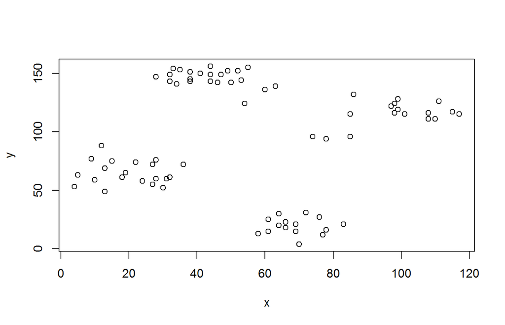

```r
## 导入数据，并且查看数据的二维分布
data(ruspini, package = "cluster")
plot(y ~ x, ruspini)
```

```r
## 定义一个任务
ruspini_tast <- makeClusterTask(data = ruspini)

## 构建学习器
lrn <- makeLearner("cluster.kmeans", centers = 4)

## 训练模型
mod <- train(lrn, ruspini_tast)
mod
```

```
## Model for learner.id=cluster.kmeans; learner.class=cluster.kmeans
## Trained on: task.id = ruspini; obs = 75; features = 2
## Hyperparameters: centers=4
```

```r
## 查看模型中的内容
names(mod)
```

```
## [1] "learner"       "learner.model" "task.desc"     "subset"
## [5] "features"      "factor.levels" "time"          "dump"
```

```r
mod$learner
```

```
## Learner cluster.kmeans from package stats,clue
## Type: cluster
## Name: K-Means; Short name: kmeans
## Class: cluster.kmeans
## Properties: numerics,prob
## Predict-Type: response
## Hyperparameters: centers=4
```

```r
mod$features
```

```
## [1] "x" "y"
```

```r
mod$time
```

```
## [1] 0
```

```r
getLearnerModel(mod)
```

```
## K-means clustering with 4 clusters of sizes 20, 23, 17, 15
##
## Cluster means:
##          x        y
## 1 20.15000  64.9500
## 2 43.91304 146.0435
## 3 98.17647 114.8824
## 4 68.93333  19.4000
##
## Clustering vector:
##  1  2  3  4  5  6  7  8  9 10 11 12 13 14 15 16 17 18 19 20 21 22 23 24 25
##  1  1  1  1  1  1  1  1  1  1  1  1  1  1  1  1  1  1  1  1  2  2  2  2  2
## 26 27 28 29 30 31 32 33 34 35 36 37 38 39 40 41 42 43 44 45 46 47 48 49 50
##  2  2  2  2  2  2  2  2  2  2  2  2  2  2  2  2  2  2  3  3  3  3  3  3  3
## 51 52 53 54 55 56 57 58 59 60 61 62 63 64 65 66 67 68 69 70 71 72 73 74 75
##  3  3  3  3  3  3  3  3  3  3  4  4  4  4  4  4  4  4  4  4  4  4  4  4  4
##
## Within cluster sum of squares by cluster:
## [1] 3689.500 3176.783 4558.235 1456.533
##  (between_SS / total_SS =  94.7 %)
##
## Available components:
##
## [1] "cluster"      "centers"      "totss"        "withinss"
## [5] "tot.withinss" "betweenss"    "size"         "iter"
## [9] "ifault"
```

## 6.3 **Further options & comments**

训练模型使用的是`train()`函数，里面有一个参数`subset`可以选择所有观测的子集进行训练。然而，一般都会采用重抽样的策略，抽选子集不是一个好的选择。还有就是对于类别不平衡问题，可以设置`weight`进行平衡，在mlr中提供了很多中处理不平衡数据的方法，详情请点击下方链接。  
https://mlr-org.github.io/mlr-tutorial/release/html/over_and_undersampling/index.html

### 6.3.1 subset

```r
## 获取观察数量
n <- getTaskSize(bh.task)

## 选择1/3的观测作为训练集
set.seed(45)
train_set <- sample(n, size = n/3)

## 训练模型
mod <- train("regr.lm", task = bh.task, subset = train_set)
mod
```

```
## Model for learner.id=regr.lm; learner.class=regr.lm
## Trained on: task.id = BostonHousing-example; obs = 168; features = 13
## Hyperparameters:
```

### 6.3.2 weights

```r
## 计算权重
target <- getTaskTargets(bc.task)
tab <- as.numeric(table(target))
w = 1/tab[target]

## 训练模型
mod <- train("classif.rpart", task = bc.task, weights = w)
mod
```

```
## Model for learner.id=classif.rpart; learner.class=classif.rpart
## Trained on: task.id = BreastCancer-example; obs = 683; features = 9
## Hyperparameters: xval=0
```

# 7 Predict

预测大概就是把新数据传入训练好的模型中，经过模型的计算返回结果的过程。上面已经介绍过如何建立模型了，那么现在需要的就是如何将新数据传入模型。在mlr包中提供了两种方式：

- 通过从task中选取子集传入（subset）
- 直接传入新数据（newdata）

注：使用mlr包进行预测的时候，不需要去剔除目标变量，它将会被自动删除。

## 7.1 **Predicting Outcomes for New Data**

下面使用BostonHousing和iris两个数据来演示两种传入数据进行预测的方式。

### 7.1.1 subset

```r
n <- getTaskSize(bh.task)
train_set <- seq(1, n, by = 2)
test_set <- seq(2, n, by = 2)

lrn <- makeLearner("regr.gbm", n.trees = 100)
mod <- train(lrn, bh.task, subset = train_set)

task_pred <- predict(mod, task = bh.task, subset = test_set)
task_pred
```

```
## Prediction: 253 observations
## predict.type: response
## threshold:
## time: 0.00
##    id truth response
## 2   2  21.6 22.22588
## 4   4  33.4 23.18013
## 6   6  28.7 22.37618
## 8   8  27.1 22.13908
## 10 10  18.9 22.13908
## 12 12  18.9 22.13908
## ... (#rows: 253, #cols: 3)
```

### 7.1.2 newdata

```r
n <- nrow(iris)
iris_train <- iris[seq(1, n, by = 2), -5]
iris_test <- iris[seq(2, n, by = 2), -5]

task <- makeClusterTask(data = iris_train)
mod <- train("cluster.kmeans", task)

newdata_pred <- predict(mod, newdata = iris_test)
newdata_pred
```

```
## Prediction: 75 observations
## predict.type: response
## threshold:
## time: 0.00
##    response
## 2         2
## 4         2
## 6         2
## 8         2
## 10        2
## 12        2
## ... (#rows: 75, #cols: 1)
```

## 7.2 **Accessing the prediction**

下面呢，我们分别用不同的方法来获取上面的两个预测的相关信息。

- 使用as.dada.frame的方式获取的信息不只是预测的结果，还会有其他信息。
- 使`getPredictionTruth()`和`getPredictionResponse()`可以获取具体的信息。

### 7.2.1 getPrediction_

```r
head(as.data.frame(task_pred))
```

```
##    id truth response
## 2   2  21.6 22.22588
## 4   4  33.4 23.18013
## 6   6  28.7 22.37618
## 8   8  27.1 22.13908
## 10 10  18.9 22.13908
## 12 12  18.9 22.13908
```

```r
head(as.data.frame(newdata_pred))
```

```
##    response
## 2         2
## 4         2
## 6         2
## 8         2
## 10        2
## 12        2
```

```r
head(getPredictionTruth(task_pred))
```

```
## [1] 21.6 33.4 28.7 27.1 18.9 18.9
```

```r
head(getPredictionResponse(task_pred))
```

```
## [1] 22.22588 23.18013 22.37618 22.13908 22.13908 22.13908
```

### 7.2.2 Regression: standard errors

```r
## 返回mlr中可以返回标准误差的回归学习器的类别和名称
head(listLearners("regr", check.packages = F, properties = "se")[c("class", "name")])
```

```
##          class
## 1   regr.bcart
## 2     regr.bgp
## 3  regr.bgpllm
## 4     regr.blm
## 5    regr.btgp
## 6 regr.btgpllm
##                                                                      name
## 1                                                           Bayesian CART
## 2                                               Bayesian Gaussian Process
## 3       Bayesian Gaussian Process with jumps to the Limiting Linear Model
## 4                                                   Bayesian Linear Model
## 5                                         Bayesian Treed Gaussian Process
## 6 Bayesian Treed Gaussian Process with jumps to the Limiting Linear Model
```

```r
## Create learner and specify predict.type
lrn_lm <- makeLearner("regr.lm", predict.type = 'se')
mod_lm <- train(lrn_lm, bh.task, subset = train_set)
task_pred_lm <- predict(mod_lm, task = bh.task, subset = test_set)
task_pred_lm
```

```
## Prediction: 253 observations
## predict.type: se
## threshold:
## time: 0.00
##    id truth response        se
## 2   2  21.6 24.83734 0.7501615
## 4   4  33.4 28.38206 0.8742590
## 6   6  28.7 25.16725 0.8652139
## 8   8  27.1 19.38145 1.1963265
## 10 10  18.9 18.66449 1.1793944
## 12 12  18.9 21.25802 1.0727918
## ... (#rows: 253, #cols: 4)
```

```r
getPredictionSE(task_pred_lm)
```

```
##   [1] 0.7501615 0.8742590 0.8652139 1.1963265 1.1793944 1.0727918 0.8429301
##   [8] 0.8501582 0.7679939 0.7978658 0.8242887 0.9518889 0.8870152 0.8855407
##  [15] 0.8701704 0.9574664 0.8840397 0.7264163 0.7792051 1.2116561 1.1769924
##  [22] 1.0915279 0.8271369 1.0202378 0.8842189 0.8842040 0.8469392 1.3276524
##  [29] 1.4106337 0.8445755 1.2408730 1.0284519 1.1041909 0.8291724 0.7543209
##  [36] 0.9929409 1.1375092 0.8367674 0.8402063 0.9082750 0.7022658 0.5771416
##  [43] 0.6308225 0.7278137 0.7811490 0.8189424 1.1384919 0.8335267 1.1364319
##  [50] 0.9138132 0.8760649 0.8655742 1.0203456 0.9359339 0.9109483 0.7508824
##  [57] 0.8448710 0.8043901 0.7906399 0.7786039 1.6494629 1.7380621 1.6491231
##  [64] 1.0193436 1.0088684 1.1054014 1.0286131 1.0927726 1.1071940 1.0774204
##  [71] 1.4149076 1.5083177 1.6783724 1.5859976 1.4461011 1.5548512 1.4818863
##  [78] 1.9595402 1.2321197 1.6034097 1.3099265 1.6743209 1.2322197 1.1830271
##  [85] 1.0915488 1.1511754 0.8948695 0.9734422 0.8509782 0.8854074 0.9652907
##  [92] 1.1272297 0.8477232 1.1092160 0.9952516 0.8699082 0.9101939 1.2047344
##  [99] 1.2692851 1.3234582 1.2451465 1.5187036 0.9656436 0.6745382 1.5195856
```

[output cut: 22 more lines]

### 7.2.3 clustering: probabilities

```r
lrn <- makeLearner("cluster.cmeans", predict.type = "prob")
mod <- train(lrn, mtcars.task)

pred <- predict(mod, task = mtcars.task)
head(getPredictionProbabilities(pred))
```

```
##                            1           2
## Mazda RX4         0.97959271 0.020407288
## Mazda RX4 Wag     0.97963293 0.020367069
## Datsun 710        0.99266074 0.007339256
## Hornet 4 Drive    0.54290616 0.457093843
## Hornet Sportabout 0.01870482 0.981295175
## Valiant           0.75745403 0.242545967
```

### 7.2.4 Classification: probabilities

```r
lrn <- makeLearner("classif.rpart", predict.type = "prob")

mod <- train(lrn, task = iris.task)

pred <- predict(mod, newdata = iris)
head(as.data.frame(pred))
```

```
##    truth prob.setosa prob.versicolor prob.virginica response
## 1 setosa           1               0              0   setosa
## 2 setosa           1               0              0   setosa
## 3 setosa           1               0              0   setosa
## 4 setosa           1               0              0   setosa
## 5 setosa           1               0              0   setosa
## 6 setosa           1               0              0   setosa
```

```r
head(getPredictionProbabilities(pred))  # 只获取概率
```

```
##   setosa versicolor virginica
## 1      1          0         0
## 2      1          0         0
## 3      1          0         0
## 4      1          0         0
## 5      1          0         0
## 6      1          0         0
```

### 7.2.5 Classifiction: Confusion matrix

```r
calculateConfusionMatrix(pred)
```

```
##             predicted
## true         setosa versicolor virginica -err.-
##   setosa         50          0         0      0
##   versicolor      0         49         1      1
##   virginica       0          5        45      5
##   -err.-          0          5         1      6
```

```r
conf_matrix <- calculateConfusionMatrix(pred, relative = T); conf_matrix
```

```
## Relative confusion matrix (normalized by row/column):
##             predicted
## true         setosa    versicolor virginica -err.-
##   setosa     1.00/1.00 0.00/0.00  0.00/0.00 0.00
##   versicolor 0.00/0.00 0.98/0.91  0.02/0.02 0.02
##   virginica  0.00/0.00 0.10/0.09  0.90/0.98 0.10
##   -err.-          0.00      0.09       0.02 0.04
##
##
## Absolute confusion matrix:
##             predicted
## true         setosa versicolor virginica -err.-
##   setosa         50          0         0      0
##   versicolor      0         49         1      1
##   virginica       0          5        45      5
##   -err.-          0          5         1      6
```

```r
conf_matrix$relative.row
```

```
##            setosa versicolor virginica -err-
## setosa          1       0.00      0.00  0.00
## versicolor      0       0.98      0.02  0.02
## virginica       0       0.10      0.90  0.10
```

### 7.2.6 Classification: Adjusting the decision threshold

```r
lrn <- makeLearner("classif.rpart", predict.type = "prob")
mod <- train(lrn, task = sonar.task)

## 查看此任务的正例
getTaskDesc(sonar.task)$positive
```

```
## [1] "M"
```

```r
## 查看默认阈值
pred1 <- predict(mod, sonar.task)
pred1$threshold
```

```
##   M   R
## 0.5 0.5
```

```r
## 自定义阈值
pred2 <- setThreshold(pred1, 0.9)
pred2$threshold
```

```
##   M   R
## 0.9 0.1
```

```r
pred2
```

```
## Prediction: 208 observations
## predict.type: prob
## threshold: M=0.90,R=0.10
## time: 0.00
##   id truth    prob.M    prob.R response
## 1  1     R 0.1060606 0.8939394        R
## 2  2     R 0.7333333 0.2666667        R
## 3  3     R 0.0000000 1.0000000        R
## 4  4     R 0.1060606 0.8939394        R
## 5  5     R 0.9250000 0.0750000        M
## 6  6     R 0.0000000 1.0000000        R
## ... (#rows: 208, #cols: 5)
```

```r
## 查看彼此的混淆矩阵
calculateConfusionMatrix(pred1)
```

```
##         predicted
## true      M  R -err.-
##   M      95 16     16
##   R      10 87     10
##   -err.- 10 16     26
```

```r
calculateConfusionMatrix(pred2)
```

```
##         predicted
## true      M  R -err.-
##   M      84 27     27
##   R       6 91      6
##   -err.-  6 27     33
```

```r
## 获取每个样本被预测为正例的概率
head(getPredictionProbabilities(pred1))
```

```
## [1] 0.1060606 0.7333333 0.0000000 0.1060606 0.9250000 0.0000000
```

```r
## 获取每个样本被预测为正例或者反例的概率
head(getPredictionProbabilities(pred1, cl = c("M", "R")))
```

```
##           M         R
## 1 0.1060606 0.8939394
## 2 0.7333333 0.2666667
## 3 0.0000000 1.0000000
## 4 0.1060606 0.8939394
## 5 0.9250000 0.0750000
## 6 0.0000000 1.0000000
```

```r
## 对于多分类同样可以设置阈值
lrn <- makeLearner("classif.rpart", predict.type = "prob")
mod <- train(lrn, iris.task)
pred <- predict(mod, newdata = iris)
pred$threshold
```

```
##     setosa versicolor  virginica
##  0.3333333  0.3333333  0.3333333
```

```r
table(as.data.frame(pred)$response)
```

```
##
##     setosa versicolor  virginica
##         50         54         46
```

```r
pred <- setThreshold(pred, c(setosa = 0.01, versicolor = 50, virginica = 1))
pred$threshold
```

```
##     setosa versicolor  virginica
##       0.01      50.00       1.00
```

```r
table(as.data.frame(pred)$response)
```

```
##
##     setosa versicolor  virginica
##         50          0        100
```

### 7.2.7 Visualizing the prediction

对于不同的任务，会默认选择数据的前两个特征进行相应的学习器的训练建立模型（可以自定义两个变量），然后就行预测，把预测结果进行可视化。 对于回归任务，得选择单一或者两个变量会产生不同的效果。

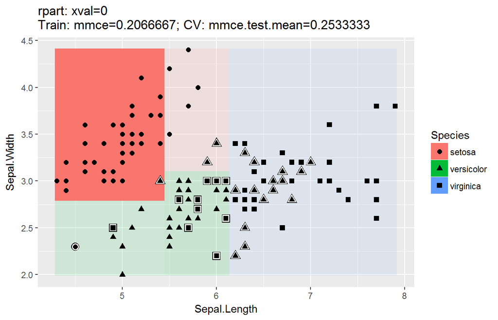

```r
## 分类任务
lrn <- makeLearner("classif.rpart", id = "CART")
plotLearnerPrediction(lrn, task = iris.task)
```

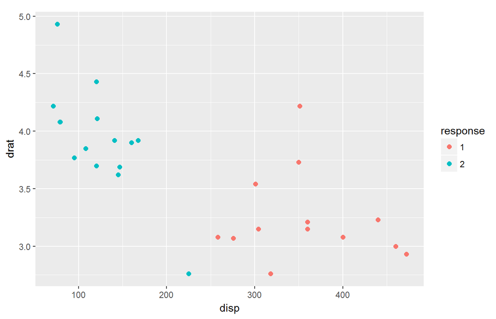

```r
## 聚类任务
lrn <- makeLearner("cluster.kmeans")
plotLearnerPrediction(lrn, task = mtcars.task, features = c("disp", "drat"), cv = 0)
```

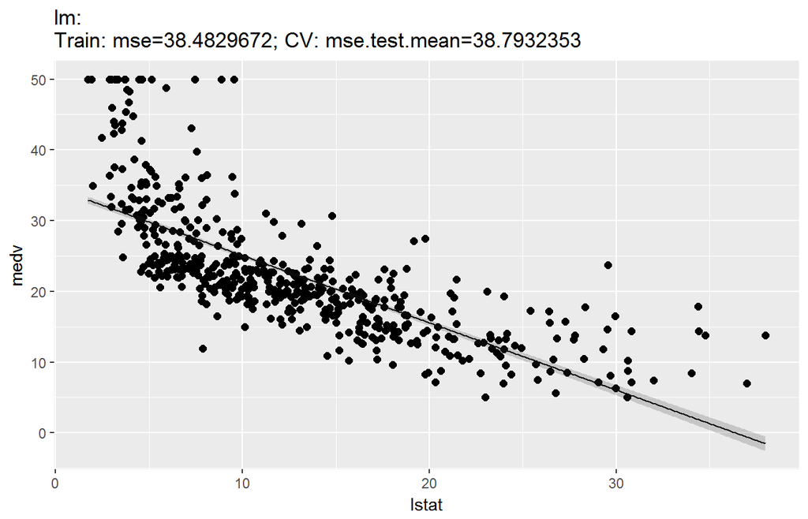

```r
## 回归任务
plotLearnerPrediction("regr.lm", features = "lstat", task = bh.task)          # 单一变量
```

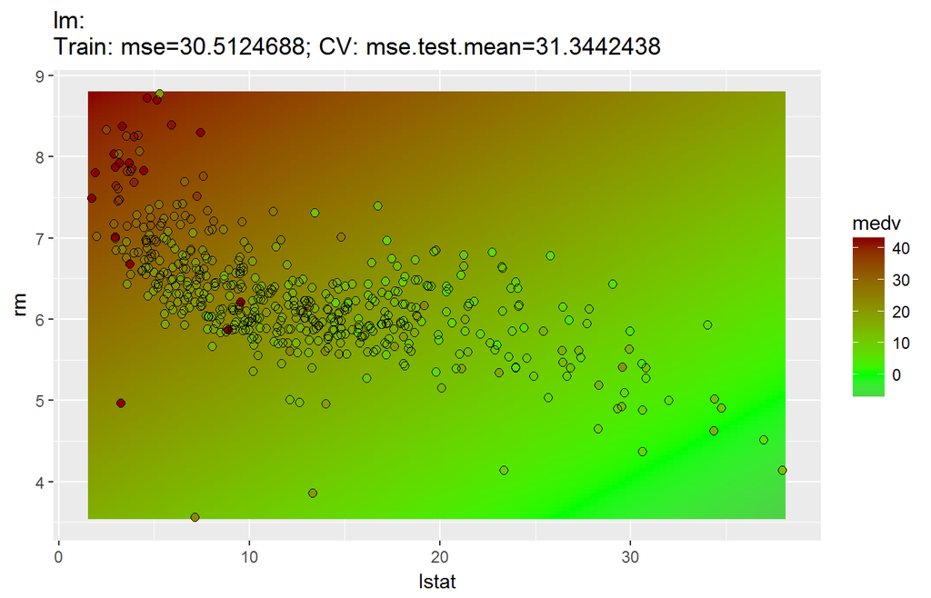

```r
plotLearnerPrediction("regr.lm", features = c("lstat", "rm"), task = bh.task) # 两个变量
```

# 8 Preprocessing(NO)

# 9 Performance

## 9.1 **Listing measures**

不同的任务有不同的评估方法，可以使用`listMeaasures()`来获取指定任务的所有评估方法。为了方便，mlr包中会针对不同的任务指定一个默认的评估方法。比如说在回归任务中，默认使用均方误差（mse），在分类任务中使用误分类率（mmce）等。如何想知道具体的默认方法，可以使用`getDefaultMeasure()`去查看各任务所对应的各种评估方法。

```r
# 查看适合多分类学习器的评估方法
listMeasures("classif", properties = "classif.multi")
```

```
##  [1] "featperc"         "mmce"             "lsr"
##  [4] "bac"              "qsr"              "timeboth"
##  [7] "multiclass.aunp"  "timetrain"        "multiclass.aunu"
## [10] "ber"              "timepredict"      "multiclass.brier"
## [13] "ssr"              "acc"              "logloss"
## [16] "wkappa"           "multiclass.au1p"  "multiclass.au1u"
## [19] "kappa"
```

```r
# 查看适合iris.task的评估方法
listMeasures(iris.task)
```

```
##  [1] "featperc"         "mmce"             "lsr"
##  [4] "bac"              "qsr"              "timeboth"
##  [7] "multiclass.aunp"  "timetrain"        "multiclass.aunu"
## [10] "ber"              "timepredict"      "multiclass.brier"
## [13] "ssr"              "acc"              "logloss"
## [16] "wkappa"           "multiclass.au1p"  "multiclass.au1u"
## [19] "kappa"
```

```r
# 查看iris.task中默认的评估方法
getDefaultMeasure(iris.task)
```

```
## Name: Mean misclassification error
## Performance measure: mmce
## Properties: classif,classif.multi,req.pred,req.truth
## Minimize: TRUE
## Best: 0; Worst: 1
## Aggregated by: test.mean
## Arguments:
## Note: Defined as: mean(response != truth)
```

```r
# 查看regr.lm中默认的评估方法
getDefaultMeasure(makeLearner("regr.lm"))
```

```
## Name: Mean of squared errors
## Performance measure: mse
## Properties: regr,req.pred,req.truth
## Minimize: TRUE
## Best: 0; Worst: Inf
## Aggregated by: test.mean
## Arguments:
## Note: Defined as: mean((response - truth)^2)
```

## 9.2 **Calculate performance meaasures**

```r
n <- getTaskSize(bh.task)
lrn <- makeLearner("regr.gbm", n.trees = 1000)
mod <- train(lrn, task = bh.task, subset = seq(1, n, 2))
pred <- predict(mod, task = bh.task, subset = seq(2, n, 2))

performance(pred)
```

```
##      mse
## 42.83207
```

```r
performance(pred, measures = medse)
```

```
##    medse
## 9.315383
```

```r
performance(pred, measures = list(mse, medse, mae))
```

```
##       mse     medse       mae
## 42.832075  9.315383  4.557009
```

## 9.3 **Requirements of performance measures**

```r
performance(pred, measures = timetrain, model = mod)
```

```
## timetrain
##      0.28
```

```r
lrn <- makeLearner("cluster.kmeans", centers = 3)
mod <- train(lrn, mtcars.task)
pred <- predict(mod, task = mtcars.task)

performance(pred, measures = dunn, task = mtcars.task)
```

```
##      dunn
## 0.1462919
```

```r
lrn <- makeLearner("classif.rpart", predict.type = "prob")
mod <- train(lrn, task = sonar.task)
pred <- predict(mod, task = sonar.task)

performance(pred, measures = auc)
```

```
##       auc
## 0.9224018
```

## 9.4 **Access a performance measure**

```r
## Mean misclassification error
str(mmce)
```

```
## List of 10
##  $ id        : chr "mmce"
##  $ minimize  : logi TRUE
##  $ properties: chr [1:4] "classif" "classif.multi" "req.pred" "req.truth"
##  $ fun       :function (task, model, pred, feats, extra.args)
##  $ extra.args: list()
##  $ best      : num 0
##  $ worst     : num 1
##  $ name      : chr "Mean misclassification error"
##  $ note      : chr "Defined as: mean(response != truth)"
##  $ aggr      :List of 4
##   ..$ id        : chr "test.mean"
##   ..$ name      : chr "Test mean"
##   ..$ fun       :function (task, perf.test, perf.train, measure, group, pred)
##   ..$ properties: chr "req.test"
##   ..- attr(*, "class")= chr "Aggregation"
##  - attr(*, "class")= chr "Measure"
```

## 9.5 **Plot performance versus threshold**

```r
## 训练模型，并预测
lrn <- makeLearner("classif.lda", predict.type = "prob")
n <- getTaskSize(sonar.task)
mod <- train(lrn, task = sonar.task, subset = seq(1, n, by = 2))
pred <- predict(mod, task = sonar.task, subset = seq(2, n, by = 2))

## 评估模型（阈值是0.5）
performance(pred, measures = list(fpr, fnr, mmce))
```

```
##       fpr       fnr      mmce
## 0.2500000 0.3035714 0.2788462
```

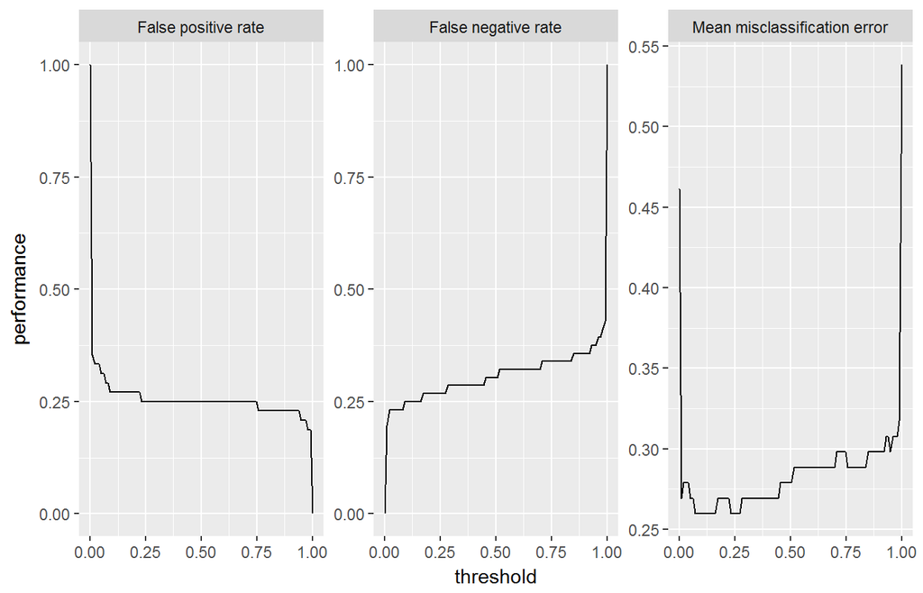

```r
## 查看不同阈值下的模型指标
d <- generateThreshVsPerfData(pred, measures = list(fpr, fnr, mmce))
plotThreshVsPerf(d)
```

## 9.6 **ROC measures**

```r
r <- calculateROCMeasures(pred); r
```

```
##     predicted
## true M         R
##    M 39        17        tpr: 0.7  fnr: 0.3
##    R 12        36        fpr: 0.25 tnr: 0.75
##      ppv: 0.76 for: 0.32 lrp: 2.79 acc: 0.72
##      fdr: 0.24 npv: 0.68 lrm: 0.4  dor: 6.88
##
##
## Abbreviations:
## tpr - True positive rate (Sensitivity, Recall)
## fpr - False positive rate (Fall-out)
## fnr - False negative rate (Miss rate)
## tnr - True negative rate (Specificity)
## ppv - Positive predictive value (Precision)
## for - False omission rate
## lrp - Positive likelihood ratio (LR+)
## fdr - False discovery rate
## npv - Negative predictive value
## acc - Accuracy
## lrm - Negative likelihood ratio (LR-)
## dor - Diagnostic odds ratio
```

# 10 Resampling

## 10.1 **Defining the resampling strategy**

mlr包中提供了6种重采样策略：

- Cross-validation (“CV”)
- Leave-one-out cross-validation (“LOO”)
- Repeated cross-validation (“RepCV”)
- Out-of-bag bootstrap and other variants like b632 (“Bootstrap”)
- Subsampling, also called Monte-Carlo cross-validation (“Subsample”)
- Holdout (training/test) (“Holdout”)

```r
## 3折交叉验证
rdesc <- makeResampleDesc("CV", iters = 3); rdesc
```

```
## Resample description: cross-validation with 3 iterations.
## Predict: test
## Stratification: FALSE
```

```r
## Holdout
rdesc <- makeResampleDesc("Holdout"); rdesc
```

```
## Resample description: holdout with 0.67 split rate.
## Predict: test
## Stratification: FALSE
```

## 10.2 **Perforing the resampling**

下面是对BostonHousing拟合其medv（因变量）值，使用了3折交叉验证的重采样策略。目前我对于最后返回的medv的理解就是三次结果取平均，因为最后的mse是三个模型mse的均值。

```r
rdesc <- makeResampleDesc("CV", iters = 3)

set.seed(45)
r <- resample("regr.lm", bh.task, rdesc); r
```

```
## Resample Result
## Task: BostonHousing-example
## Learner: regr.lm
## Aggr perf: mse.test.mean=24.0414320
## Runtime: 0.044003
```